# Differential abundance testing with Milo

Local version, reads from the workshop data repo, no network access

Published

August 4, 2026

Local rework of `3_b_composition_milo.html`.

Upstream: https://bioconductor.org/packages/release/bioc/vignettes/miloR/inst/doc/milo_gastrulation.html

Method: Dann et al. 2022, “Differential abundance testing on single-cell data using k-nearest neighbor graphs”, Nature Biotechnology, https://doi.org/10.1038/s41587-021-01033-z

Dataset: Pijuan-Sala et al. 2019, “A single-cell molecular map of mouse gastrulation and early organogenesis”, Nature, https://doi.org/10.1038/s41586-019-0933-9

**ImportantStatus: transcribed from upstream, first render is a test**

**CautionDo not put the download back**

Upstream calls `EmbryoAtlasData()`, which pulls the mouse gastrulation atlas through `ExperimentHub`. `ExperimentHub` caches per user, so twenty students on twenty accounts means twenty multi-GB downloads at the same moment. That call is deliberately absent here. It lives in `staging/stage_3_b_composition_milo.R` and is run once, ahead of time.

## Setup

```r
data_dir <- "~/MEGA/workshop_data/3_b_composition_milo"
in_data_dir <- function(basename) {
  return(file.path(data_dir, basename))
}
```

```r
suppressPackageStartupMessages({
  library(miloR)
  library(SingleCellExperiment)
  library(scater)
  library(scran)
  library(dplyr)
  library(patchwork)
  library(ggplot2)
})
```

## Load data

**NoteStaged file**

`embryo_atlas_subset.rds`, a `SingleCellExperiment`. Produced by `staging/stage_3_b_composition_milo.R`, which is where the `EmbryoAtlasData()` call and the NA filter live.

```r
embryo_data <- readRDS(file.path(data_dir, "embryo_atlas_subset.rds"))
embryo_data
```

```
class: SingleCellExperiment
dim: 29452 6875
metadata(0):
assays(1): counts
rownames(29452): ENSMUSG00000051951 ENSMUSG00000089699 ...
  ENSMUSG00000096730 ENSMUSG00000095742
rowData names(2): ENSEMBL SYMBOL
colnames(6875): cell_361 cell_362 ... cell_29013 cell_29014
colData names(17): cell barcode ... colour sizeFactor
reducedDimNames(2): pca.corrected umap
mainExpName: NULL
altExpNames(0):
```

## Visualize the data

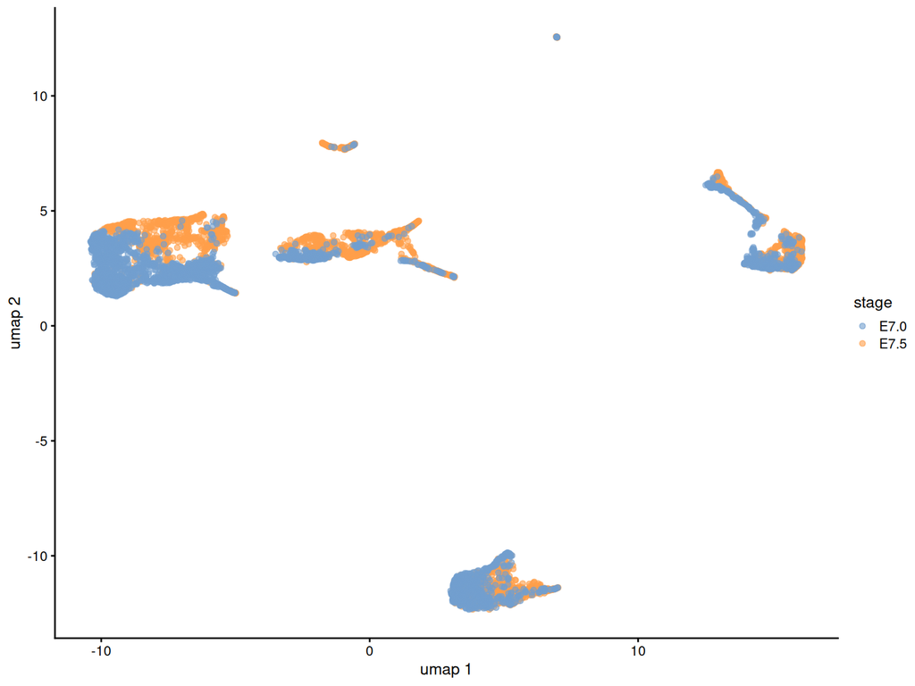

```r
embryo_data <- runUMAP(embryo_data, dimred = "pca.corrected", name = "umap")
plotReducedDim(embryo_data, colour_by = "stage", dimred = "umap")
```

## Create a Milo object

`Milo` extends `SingleCellExperiment` with slots for the neighbourhoods.

```r
embryo_milo <- Milo(embryo_data)
embryo_milo
```

```
class: Milo
dim: 29452 6875
metadata(0):
assays(1): counts
rownames(29452): ENSMUSG00000051951 ENSMUSG00000089699 ...
  ENSMUSG00000096730 ENSMUSG00000095742
rowData names(2): ENSEMBL SYMBOL
colnames(6875): cell_361 cell_362 ... cell_29013 cell_29014
colData names(17): cell barcode ... colour sizeFactor
reducedDimNames(2): pca.corrected umap
mainExpName: NULL
altExpNames(0):
nhoods dimensions(2): 1 1
nhoodCounts dimensions(2): 1 1
nhoodDistances dimension(1): 0
graph names(0):
nhoodIndex names(1): 0
nhoodExpression dimension(2): 1 1
nhoodReducedDim names(0):
nhoodGraph names(0):
nhoodAdjacency dimension(2): 1 1
```

## Construct the KNN graph

`k` affects the power of the test, because each neighbourhood needs enough cells per sample to estimate between-replicate variance. Too large and it over-smooths. Start with the same `k` you used for clustering and UMAP.

```r
embryo_milo <- buildGraph(embryo_milo, k = 30, d = 30,
                          reduced.dim = "pca.corrected")
```

## Define representative neighbourhoods

`prop` is the fraction of cells sampled as neighbourhood indices. `refined = TRUE` is the recommended sampling scheme.

```r
embryo_milo <- makeNhoods(embryo_milo, prop = 0.1, k = 30, d = 30,
                          refined = TRUE, reduced_dims = "pca.corrected")
```

Rule of thumb: mean neighbourhood size should be above 5 times the number of samples. If it is lower, raise `k` or `prop` and rebuild.

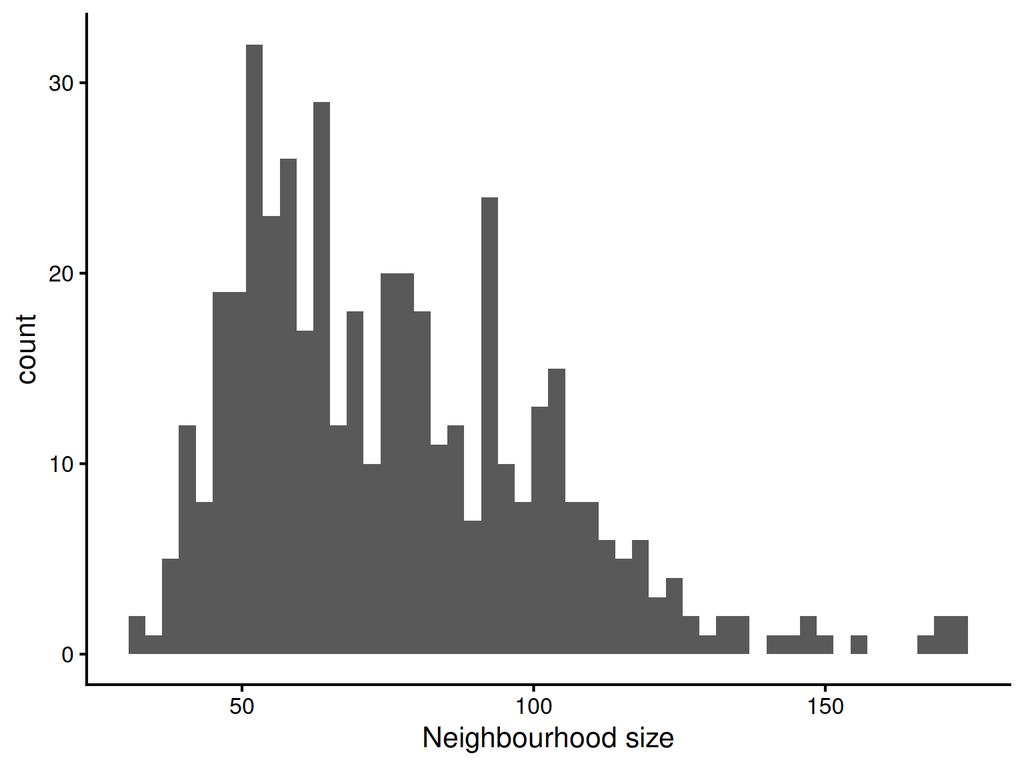

```r
plotNhoodSizeHist(embryo_milo)
```

## Count cells in neighbourhoods

Milo uses the variation in cell numbers between replicates of the same condition to test for differential abundance, so the counting is by sample.

```r
embryo_milo <- countCells(embryo_milo,
                          meta.data = as.data.frame(colData(embryo_milo)),
                          sample = "sample")
head(nhoodCounts(embryo_milo))
```

```
6 x 6 sparse Matrix of class "dgCMatrix"
  2 3  6  4 10 14
1 1 9 51  5 18 20
2 1 2 31  6 33  2
3 6 6 77 14 13  7
4 6 9 32  2  4  1
5 . .  5  . 46 12
6 . 1  1  . 15 67
```

## Defining the experimental design

Testing is a negative binomial GLM from edgeR. The design matrix maps each sample to its condition, here `stage`, plus `sequencing.batch` as a known technical covariate.

**TipWorth lingering on**

This is the same design-matrix idea as DESeq2 in `2_a_pseudobulk_de_local.qmd`, applied to neighbourhood counts instead of gene counts.

```r
embryo_design <- data.frame(colData(embryo_milo))[,
  c("sample", "stage", "sequencing.batch")]

# Batch is stored as an integer, and must be a factor.
embryo_design$sequencing.batch <- as.factor(embryo_design$sequencing.batch)
embryo_design <- dplyr::distinct(embryo_design)
rownames(embryo_design) <- embryo_design$sample

embryo_design
```

```
   sample stage sequencing.batch
2       2  E7.5                1
3       3  E7.5                1
6       6  E7.5                1
4       4  E7.5                1
10     10  E7.0                1
14     14  E7.0                2
```

## Computing neighbourhood connectivity

Milo adapts the spatial FDR correction from cydar, weighting each p-value by the reciprocal of the kth nearest neighbour distance. Those distances have to be stored first.

```r
# This is the slowest step in the workflow.
embryo_milo <- calcNhoodDistance(embryo_milo, d = 30,
                                 reduced.dim = "pca.corrected")
```

## Testing

```r
da_results <- testNhoods(embryo_milo,
                         design = ~ sequencing.batch + stage,
                         design.df = embryo_design,
                         reduced.dim = "pca.corrected")
head(da_results)
```

```
       logFC   logCPM          F       PValue          FDR Nhood   SpatialFDR
1  0.3504901 11.92446  0.1411141 7.072351e-01 7.402064e-01     1 7.419391e-01
2 -1.1784124 11.31634  1.8702615 1.716733e-01 2.083278e-01     2 2.108835e-01
3  1.5904193 12.07099  2.5321528 1.117826e-01 1.421824e-01     3 1.451587e-01
4  2.3545939 11.11242  4.5283526 3.351884e-02 4.708742e-02     4 4.856669e-02
5 -4.6617263 11.24813 22.6362798 2.168267e-06 1.315611e-05     5 1.104164e-05
6 -3.9313575 12.26734 10.3696729 1.311599e-03 2.484843e-03     6 2.493942e-03
```

```r
da_results |>
  dplyr::arrange(SpatialFDR) |>
  head(20)
```

```
        logFC   logCPM        F       PValue          FDR Nhood   SpatialFDR
139 -8.663729 11.68641 43.10823 7.374261e-11 3.311043e-08   139 2.527979e-08
88  -6.778448 11.75283 40.42551 2.790464e-10 6.264591e-08    88 4.708244e-08
105 -8.032470 11.00602 38.35893 7.802510e-10 1.007399e-07   105 7.699449e-08
146 -5.762725 11.85006 38.07808 8.974605e-10 1.007399e-07   146 7.699449e-08
152 -6.238315 11.83390 37.61740 1.129179e-09 1.014003e-07   152 7.699449e-08
366 -5.926242 12.03526 36.64768 1.832042e-09 1.370978e-07   366 1.039531e-07
30  -6.627494 11.06964 35.81258 2.780696e-09 1.783618e-07    30 1.369859e-07
434 -6.097171 11.77379 35.43329 3.361494e-09 1.886638e-07   434 1.447321e-07
20  -5.558769 11.74952 34.46676 5.453234e-09 1.917376e-07    20 1.493113e-07
51  -7.910103 11.28672 34.31173 5.893668e-09 1.917376e-07    51 1.493113e-07
62  -6.082112 11.14564 34.12455 6.473248e-09 1.917376e-07    62 1.493113e-07
75  -5.550465 11.59379 34.03965 6.754648e-09 1.917376e-07    75 1.493113e-07
87  -6.015602 11.67736 34.40789 5.616464e-09 1.917376e-07    87 1.493113e-07
301 -6.199458 11.31755 34.01678 6.832520e-09 1.917376e-07   301 1.493113e-07
320 -5.635518 11.94181 34.66801 4.930366e-09 1.917376e-07   320 1.493113e-07
446 -5.877879 11.37921 34.30403 5.916459e-09 1.917376e-07   446 1.493113e-07
189 -5.772804 11.42094 33.08578 1.089923e-08 2.878680e-07   189 2.237943e-07
168 -5.750945 11.38506 32.60267 1.389169e-08 3.234938e-07   168 2.509751e-07
278 -5.705369 11.76539 32.70128 1.322035e-08 3.234938e-07   278 2.509751e-07
350 -5.535021 11.77566 32.52981 1.440952e-08 3.234938e-07   350 2.509751e-07
```

## Inspecting the results

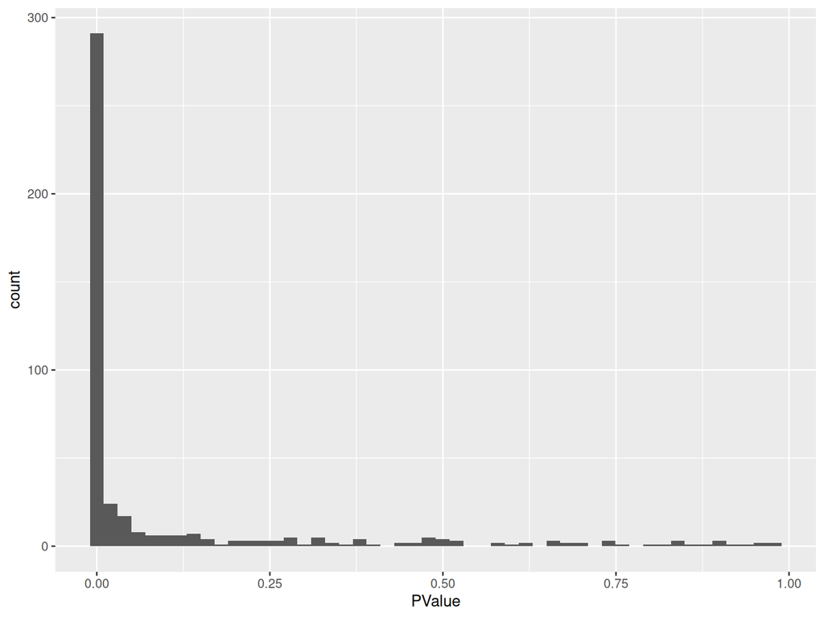

```r
ggplot(da_results, aes(PValue)) + geom_histogram(bins = 50)
```

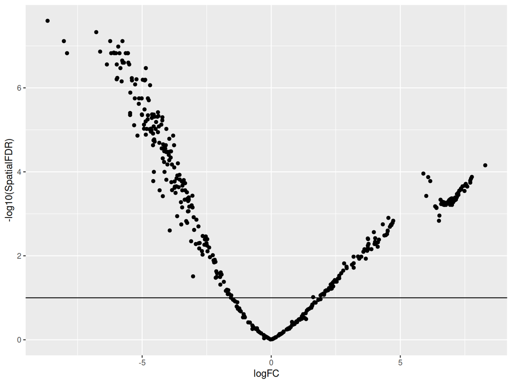

```r
ggplot(da_results, aes(logFC, -log10(SpatialFDR))) +
  geom_point() +
  geom_hline(yintercept = 1)   # 10% FDR
```

Each node is a neighbourhood, edges show how many cells two neighbourhoods share, and node position comes from the index cell’s position in the single-cell UMAP. Significant neighbourhoods are coloured by log fold change.

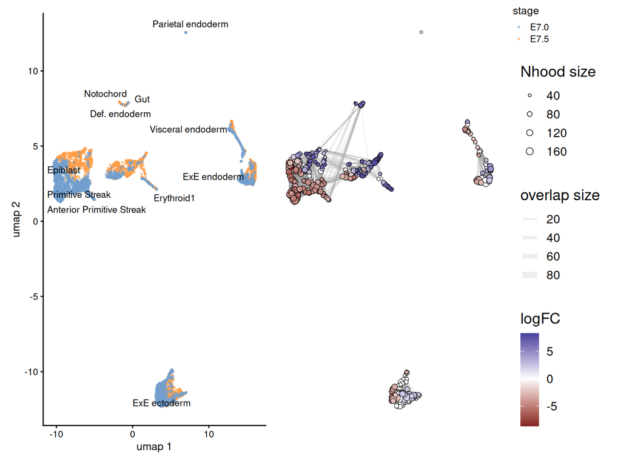

```r
embryo_milo <- buildNhoodGraph(embryo_milo)

umap_pl <- plotReducedDim(embryo_milo, dimred = "umap", colour_by = "stage",
                          text_by = "celltype", text_size = 3,
                          point_size = 0.5) +
  guides(fill = "none")

nh_graph_pl <- plotNhoodGraphDA(embryo_milo, da_results, layout = "umap",
                                alpha = 0.1)

umap_pl + nh_graph_pl + plot_layout(guides = "collect")
```

## Differential abundance by cell type

Label each neighbourhood by its most abundant cell type, and record what fraction of the neighbourhood carries that label.

```r
da_results <- annotateNhoods(embryo_milo, da_results, coldata_col = "celltype")
head(da_results)
```

```
       logFC   logCPM          F       PValue          FDR Nhood   SpatialFDR
1  0.3504901 11.92446  0.1411141 7.072351e-01 7.402064e-01     1 7.419391e-01
2 -1.1784124 11.31634  1.8702615 1.716733e-01 2.083278e-01     2 2.108835e-01
3  1.5904193 12.07099  2.5321528 1.117826e-01 1.421824e-01     3 1.451587e-01
4  2.3545939 11.11242  4.5283526 3.351884e-02 4.708742e-02     4 4.856669e-02
5 -4.6617263 11.24813 22.6362798 2.168267e-06 1.315611e-05     5 1.104164e-05
6 -3.9313575 12.26734 10.3696729 1.311599e-03 2.484843e-03     6 2.493942e-03
          celltype celltype_fraction
1   Mixed mesoderm         0.7403846
2         Epiblast         0.9066667
3     ExE ectoderm         1.0000000
4  Caudal epiblast         0.4629630
5 Nascent mesoderm         0.9841270
6         Epiblast         0.9880952
```

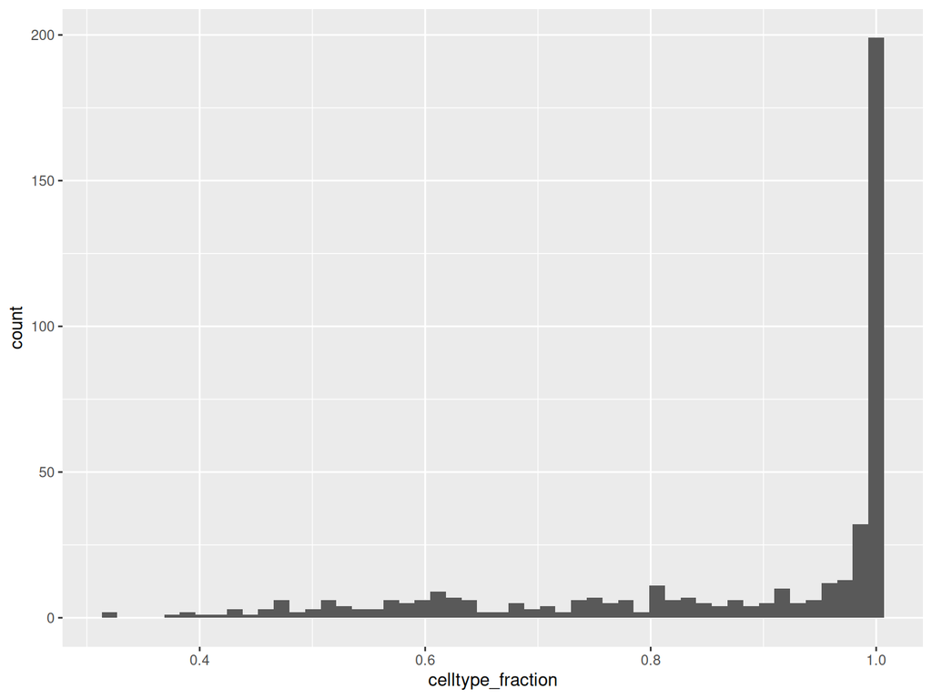

```r
ggplot(da_results, aes(celltype_fraction)) + geom_histogram(bins = 50)
```

```r
# Neighbourhoods that are a blend of cell types get called Mixed rather than
# being forced into one label.
da_results$celltype <- ifelse(da_results$celltype_fraction < 0.7,
                              "Mixed", da_results$celltype)
```

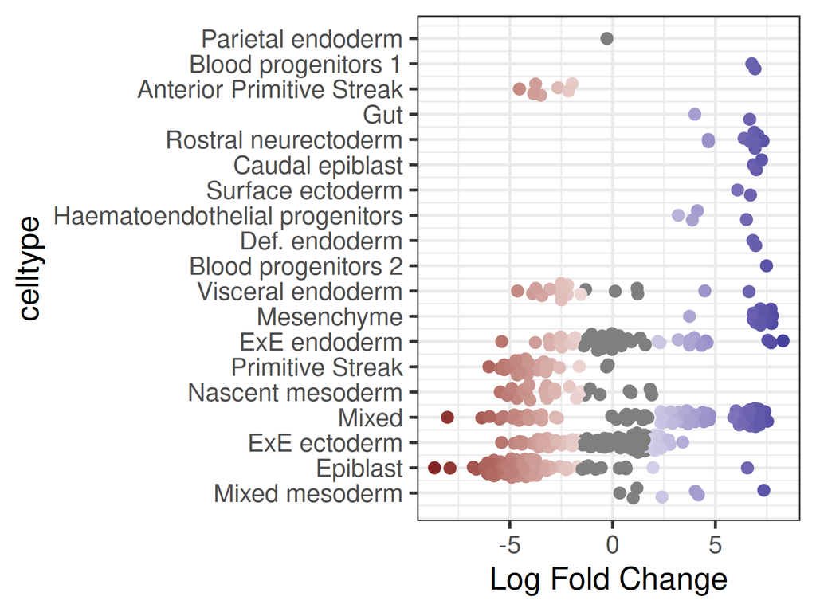

```r
plotDAbeeswarm(da_results, group.by = "celltype")
```

**TipThe teaching payoff**

Early types such as epiblast and primitive streak are enriched at the earlier stage, ectoderm later. Note the “Mixed” neighbourhoods that also come up significant. Those are transitional states, and they are exactly what a cluster-level test would have averaged away. That is the argument for Milo over `propeller` or `scCODA` in continuum data.

## Finding markers of DA populations

`findNhoodGroupMarkers` runs a one-versus-all differential expression test for a group of neighbourhoods. The grouping has to be defined first, in a `NhoodGroup` column.

```r
embryo_milo <- logNormCounts(embryo_milo)
```

```r
# Group the significant neighbourhoods that shifted in one direction against
# everything else. subset.row restricts to 10 genes for illustration, exactly as
# upstream does. Drop that argument for a real analysis.
da_results$NhoodGroup <- as.numeric(da_results$SpatialFDR < 0.1 &
                                    da_results$logFC < 0)
da_nhood_markers <- findNhoodGroupMarkers(
  embryo_milo, da_results,
  subset.row = rownames(embryo_milo)[1:10])
head(da_nhood_markers)
```

```
              GeneID       logFC_0  adj.P.Val_0       logFC_1  adj.P.Val_1
1 ENSMUSG00000025900 -0.0002256856 1.000000e+00  0.0002256856 1.000000e+00
2 ENSMUSG00000025902  0.1051442234 6.259253e-05 -0.1051442234 6.259253e-05
3 ENSMUSG00000025903 -0.0770512787 6.046175e-04  0.0770512787 6.046175e-04
4 ENSMUSG00000033813 -0.0625576561 8.390664e-03  0.0625576561 8.390664e-03
5 ENSMUSG00000033845 -0.0465802641 9.381629e-02  0.0465802641 9.381629e-02
6 ENSMUSG00000051951  0.0000000000 1.000000e+00  0.0000000000 1.000000e+00
```